# xv20220623_3_interactions_data

x.vergara

2022-09-27

# Script to generate figure #3 in the paper.

Fig. 3: Proteins that physically interact tend to have similar CCD patterns. (A) Distributions of pair-wise similarity scores for CCD patterns across the 25 chromatin features, between interacting proteins (red; 118 pairs) and between randomly picked protein pairs (mean  s.d. of 1,000 draws of 118 ran-dom pairs). (B) Mean similarity score of 118 interacting protein pairs (red line) compared to the distribu-tion of mean similarity scores of 1,000 random draws as in (A) (grey histogram), indicating that high sim-ilarities of CCD patterns of interacting protein pairs cannot be explained by random chance (p<0.001). (C) Uniform Manifold Approximation and Projection (UMAP) visualization of proteins with CCDs. Each dot represents a protein, with the shape indicating the type of synergy. Color clouds show the major chromatin state that explains each CCD. Three ‘cliques’ of four interacting proteins are shown as col-ored quadrangles. Proteins shared between multiple cliques are marked by concentric circles with the color of each clique they are part of. (D-H) CCD similarity score matrix of proteins in ATM clique (D), FA clique (E), mixed clique (F), ATM signaling (G) and DNAPKcs KO and inhibition (H). I-M) M- and N-synergies discussed in the text. Column labels are names of proteins or the inhibitor used (‘i’ suffix). Proteins or inhibitors with significant CCDs (FDRCCD < 0.05) are marked with an asterisk. Chromatin fea-tures are colored as in Fig. 1C. (I) ATM signaling. (J) Fanconi anemia complex. (K) SMC5/6 complex. (L) DNAPKcs KO and inhibition. (M) BRCA1-A complex.

```r
knitr::opts_chunk$set(root.dir = '/home/x.vergara/XV_P3_ChromDSBScreen/xv_CRISPR_screen_figures/rmarkdown/xv20210920_paper_scripts/short_version/knit_html/')

StartTime <-Sys.time()
library(knitr)

# 8-digit Date tag:
Date <- substr(gsub("-","",Sys.time()),1,8)

#Change in.dir accordingly
in.dir <- "/home/x.vergara/XV_P3_ChromDSBScreen/xv_CRISPR_screen_figures/"

#Check if output contain datetag
saveRDS_proof <- function(object, file) {
  document_path <- rstudioapi::getSourceEditorContext()$path %>% str_split(pattern = "/") %>% unlist()
  document_name <- document_path[length(document_path)]
  sys_time <- Sys.time()
  if (grepl(Date, file) == T) {
    saveRDS(object, file)
    #write(c(document_name, as.character(sys_time),"Output", correct_file), file = paste0(in.dir,"log"), ncolumns = 4, sep = "\t", append = T)
  }
  else {
    print("Incorrect datetag!")
  }
}

#Read rds check through different versions
readRDS_proof <- function(path, pat) {
  full.path <- paste0(in.dir, path)
  document_path <- rstudioapi::getSourceEditorContext()$path %>% str_split(pattern = "/") %>% unlist()
  document_name <- document_path[length(document_path)]
  sys_time <- Sys.time()

  if(file.exists(full.path) == T){
    if(paste0(in.dir,path) != getwd()){
      setwd(paste0(in.dir, path))
  }
    file.list <- list.files(pattern = pat)
    correct_file <- str_sort(file.list, decreasing = T)[1]
    print(correct_file)
    base::readRDS(file = correct_file)
    #write(c(document_name,as.character(sys_time) ,"Input", correct_file), file = paste0(in.dir,"log"), ncolumns = 4, sep = "\t", append = T)

  }
  else{
  setwd(path)
  file.list <- list.files(pattern = pat)
  correct_file <- str_sort(file.list, decreasing = T)[1]
  print(correct_file)
  base::readRDS(file = correct_file)
  #write(c(document_name, as.character(sys_time),"Input", correct_file),file = paste0(in.dir,"log"), ncolumns = 4, sep = "\t", append = T)
  }
}
```

# Libraries

```r
# setwd
setwd(in.dir)

# libraries:
library(tidyverse)
library(reshape2)
library(broom)
library(ggrepel)
library(dendextend)
```

```r
library(umap)
library(igraph)
library(lsa)
library(tibble)
library(utils)
library(base)
library(scales)
library(openxlsx)
```

# Input files for this script: All these scripts will come from the processed_data

```r
# setwd
setwd(in.dir)

#DNA repair protein KO CCD analysis
table_S3_CCDs <- readRDS_proof("data/processed_data/","S7")
```

```
## [1] "xv20220927_Table_S7_DR_screen_results.rds"
```

```r
#Filter previous data table only for significant CCDs: Created here
significant_proteins <- table_S3_CCDs %>% filter(CCD_model_p_adj < 0.05) %>% na.omit() #Melt
ddr_significant_CCDs_dcast <- significant_proteins %>% reshape2::dcast(gene ~ chrom_feature, value.var = "CCD_synergy_score") %>% column_to_rownames(var = "gene") #dcast

#Cluster data (named as cluster tibble)
cluster_tibble <- readRDS_proof("data/processed_data","DR_CCD_cluster_data")
```

```
## [1] "xv20220927_DR_CCD_cluster_data.rds"
```

```r
#Inhibitor data
CCD_inhibitors_data <- readRDS_proof("data/processed_data/","drug_CCD")
```

```
## [1] "xv20220927_drug_CCD_results.rds"
```

```r
# heatmap chromatin order
heatmap.chromatin.order <- c("HDAC3","LMNB1","late_replicating","H3K9me2","H3K9me3","HDAC1","EZH2","H3K27me3","CTCF","SMC3","m5C","HDAC2","POL2","POL2AS2","H3K36me3","TTseq","Dam","H3K79me2","H2AFZ","DNAse","H3K4me3","H4K5acK8ac","H3K4me1","H3K27ac","H3K4me2")
```

# Import BIOgrid database

```r
# setwd
setwd(in.dir)

#Import human database
human.biogrid.database <- read.table(file = "import/BIOGRID_database/xv20220530_BIOGRID-ALL-4.4.209.tab3.txt", sep = "\t", fill = T)[c(1,4,5,8,9,12,13,14,36,37)] %>% filter(V36 == "Homo sapiens" & V37 == "Homo sapiens")

#Human physical biogrid database
h.physical.biogrid.db <- human.biogrid.database %>% filter(V13 == "physical" & !V12 %in% c("Biochemical Activity","Far Western","Protein-RNA","Protein-peptide","Reconstituted Complex"))

#filter significant proteins
significant_protein.vector <- c(significant_proteins$gene %>% unique(), "BRE","C19orf40","NDNL2","C20orf196","OBFC1","UFD1L") #Vector with significant proteins
ddr.ccd.physical.biogrid.db <- h.physical.biogrid.db %>% filter(V8 %in% significant_protein.vector & V9 %in% significant_protein.vector) #Filter interaction database for interaction happening between proteins with CCDs

#Change colnames
colnames(ddr.ccd.physical.biogrid.db) <- c("interaction_ID","gene1_ID", "gene2_ID", "gene1","gene2","int_method","int_type","publication","sp_gene1", "sp_gene2")

#Repair names to match screening data
ddr.ccd.physical.biogrid.rep.db <- ddr.ccd.physical.biogrid.db %>% mutate(gene1 = case_when(gene1 == "BRE" ~ "BABAM2",
                                                                                               gene1 == "C19orf40" ~"FAAP24",
                                                                                               gene1 == "NDNL2" ~ "NSMCE3",
                                                                                               gene1 == "C20orf196" ~ "SHILD1",
                                                                                               gene1 == "OBFC1" ~ "STN1",
                                                                                               gene1 == "UFD1L" ~ "UFD1",
                                                                                               T ~ gene1),
                                                                          gene2 = case_when(gene2 == "BRE" ~ "BABAM2",
                                                                                               gene2 == "C19orf40" ~"FAAP24",
                                                                                               gene2 == "NDNL2" ~ "NSMCE3",
                                                                                               gene2 == "C20orf196" ~ "SHILD1",
                                                                                               gene2 == "OBFC1" ~ "STN1",
                                                                                               gene2 == "UFD1L" ~ "UFD1",
                                                                                               T ~ gene2))

#Unique interactions
interacting_pairs <- ddr.ccd.physical.biogrid.db %>% dplyr::select(gene1,gene2) %>% distinct() %>% dim()
```

# Figure 3A-B: Calculate cosine distances for hits

### Data processing

```r
# setwd
setwd(in.dir)

#Create a dataframe with all possible protein pairs
signif.protein.vector.ddr <- significant_proteins %>% pull(gene) %>% unique() #Get gene vector with CCDs
comb_signif.ddr <- combn(signif.protein.vector.ddr, 2, simplify = F) #Create all possible protein pairs between DR prots with CCDs
comb_signif_dt.ddr <- do.call("rbind", comb_signif.ddr) %>% as.data.frame() #Create data frame
colnames(comb_signif_dt.ddr) <- c("gene1","gene2") #Change column names

#Calculate cosine distances between each gene
cos.distance <- cosine(t(as.matrix(ddr_significant_CCDs_dcast))) #as.matrix
melt.dist.matrix <- reshape2::melt(cos.distance) #as.tibble
colnames(melt.dist.matrix) <- c("gene1", "gene2", "cos.distance") #Change column names

#Filter out redundant pairs (A-B & B-A): There is no directionality in these interactions
dist.matrix.int.biogrid <-comb_signif_dt.ddr %>% left_join(melt.dist.matrix)
#Add interaction data to all possible pairs
dist.int.partners.biogrid <- dist.matrix.int.biogrid %>%
  left_join(ddr.ccd.physical.biogrid.rep.db) %>% #Add interaction data
  mutate(interaction = case_when(is.na(int_type) ~ FALSE, T ~ TRUE)) %>% #Does each pair interact or not?
  dplyr::group_by(gene1, gene2, cos.distance) %>% #Clean possible redundant pairs in BioGRID
  dplyr::summarise(interaction = case_when(sum(interaction) == 0 ~ F, T ~ T)) #Summarize phyisical interactions
#Summary numbers of interaction
summary_interacting_pairs <- dist.int.partners.biogrid %>% dplyr::group_by(interaction) %>% dplyr::summarise(c = n())

#Sample random pairs
sample_correlations.ddr.biogrid <- tibble() #Empty tibble for sampling
n.interacting.biogrid <- dist.int.partners.biogrid %>% filter(interaction == T) %>% nrow() #Number of physical interactions in our data

#Sampling loop to select random samples of equal size as interacting pairs
   for (i in c(1:1000)){ #n=1000
  set.seed(i)
  t <- dist.int.partners.biogrid %>% ungroup() %>% sample_n(n.interacting.biogrid) %>% mutate(seed =i)
  sample_correlations.ddr.biogrid <- sample_correlations.ddr.biogrid %>% bind_rows(t)
   }

#Create density matrices for plotting later
density.matrix.datapoints <- tibble()
for (i in c(1:1000)){
  seed.unique <- filter(sample_correlations.ddr.biogrid, seed == i) %>% pull(cos.distance)%>% as.numeric()
  dens.seed.unique <- density(seed.unique, from = -1, to = 1) %>% tidy() %>% mutate(seed = i) %>% mutate(round_x = round(x, digits = 2)) %>% dplyr::group_by(round_x) %>% dplyr::summarise(mean_y = mean(y), seed = i)
  density.matrix.datapoints <- density.matrix.datapoints %>% bind_rows(dens.seed.unique)
}

#Calculate mean and sd to plot in density plots for random effects
summarise.mean.sd_sample <- density.matrix.datapoints %>% dplyr::group_by(round_x) %>% dplyr::summarise(avg_y = mean(mean_y), sd_y = sd(mean_y), counts = n())

#Calculate real interaction density data
interacting.prots <- filter(dist.int.partners.biogrid, interaction == T)
real_density_plot <- density(interacting.prots %>% pull(cos.distance), from = -1, to = 1) %>% tidy()
```

### Plotting code

#### Figure 3A: Density plots of interacting pairs

1. Distributions of pair-wise similarity scores for CCD patterns across the 25 chromatin features, between interacting proteins (red; 118 pairs) and between randomly picked protein pairs (mean  s.d. of 1,000 draws of 118 ran-dom pairs).

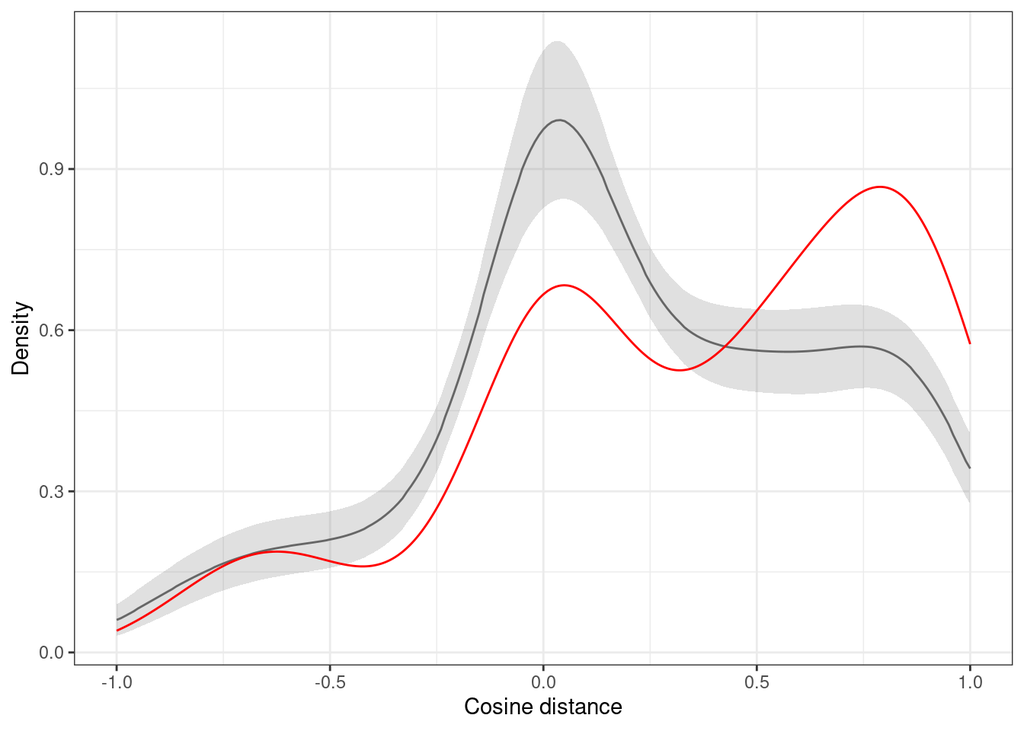

```r
ggplot(summarise.mean.sd_sample) +
  geom_ribbon(aes(round_x, ymax = avg_y + sd_y, ymin = avg_y - sd_y), alpha = 0.2, fill = "grey40") +
  geom_line(aes(round_x,avg_y), color = "grey40") +
  geom_line(data = real_density_plot, aes(x,y), color = "red") +
    theme_bw() + theme(legend.position = "top") +
  ylab("Density") + xlab("Cosine distance")
```

#### Figure 3B: Random mean distribution

2. Mean similarity score of 118 interacting protein pairs (red line) compared to the distribution of mean similarity scores of 1,000 random draws as in (A) (grey histogram), indicating that high similarities of CCD patterns of interacting protein pairs cannot be explained by random chance (p<0.001).

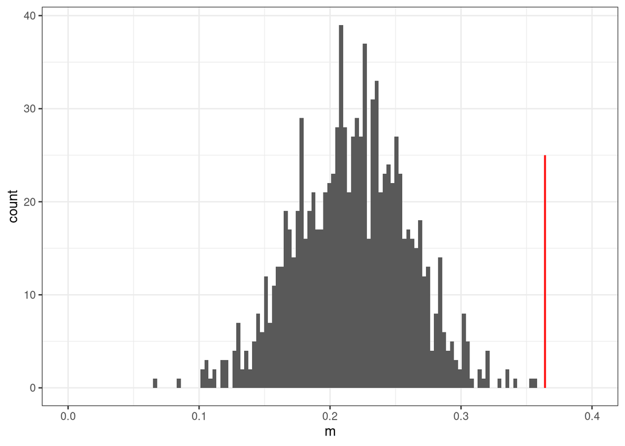

```r
#Figure 3B: Random mean distributions
sample_correlation_ddr_mean_biogrid <- sample_correlations.ddr.biogrid %>% dplyr::group_by(seed) %>% dplyr::summarise(m = mean(cos.distance))
normal_fit_data <-
real_correlation_mean_biogrid <- dist.int.partners.biogrid %>% filter(interaction == T) %>% pull(cos.distance) %>% mean()

ggplot(sample_correlation_ddr_mean_biogrid) +
  geom_histogram(aes(m), bins = 100) +
  geom_linerange(aes(real_correlation_mean_biogrid,ymin = 0, ymax = 25),color = "red") +
  coord_cartesian(expand = T, xlim = c(0,0.4)) +
  theme_bw()
```